# Advent of Code 2021: Day 8

[Day 8](https://adventofcode.com/2021/day/8) of Advent of Code 2021 asks us to identify digits from a scrambled seven segment display. Describing the problem in detail takes some time, so please visit the link above and read the description there. If you have not logged in and completed part 1, you will not see the description of part 2, but part 2 basically requires decoding all the digits in the output section (not just 1, 4, 7, and 8)

I started this Advent of Code as an opportunity to learn a new language, Racket, and it was going well. But as happens whenever learning any new skill or language, simple problems were taking much longer than I anticipated due to the unfamiliarity, and I was slowly losing steam.

When day 8 rolled around, I completely stalled out. Not so much because the problem was too difficult, but rather because it was so interesting with many potential solutions that I got completely side tracked.

First, my (probably very amateurish) Racket code I used to solve part 2:

```
#lang racket

(define decoder-map #hash(((3 . 2) . 0) ((1 . 7) . 1) ((1 . 2) . 2) ((3 . 3) . 3) ((2 . 3) . 4) ((1 . 4) . 5) ((2 . 2) . 6) ((2 . 5) . 7) ((10 . 1) . 8) ((6 . 2) . 9)))
(define (group-to-id gstr)
  (foldl (lambda (a res) (bitwise-ior res (arithmetic-shift 1 (- (char->integer a) 97)))) 0 (string->list gstr)))

(define (compute-key pat allpats)
  (cons
   (count (lambda (x) (eq? x (bitwise-and x pat))) allpats)
   (count (lambda (x) (eq? pat (bitwise-and x pat))) allpats)))

(define (solve patterns outputs)
  (let ([puzzle-map (for/hash ([x patterns])
                      (values x (hash-ref decoder-map (compute-key x patterns))))])
    (map (lambda (x) (hash-ref puzzle-map x)) outputs)))

(printf "solution: ~a\n"
(for/sum ([line (in-lines)])
  (let* ([parts (string-split line " | ")]
         [patstr (string-split (car parts))]
         [outstr (string-split (cadr parts))]
         [solved (solve (map group-to-id patstr) (map group-to-id outstr))])
    (for/sum ([i '(1000 100 10 1)] [j solved]) (* i j)))))
```

We can represent the sets of segments (strings) as a 7-bit integer where the bits are set if the corresponding segment is in the set. (For example, 'a' in the set/string = bit 0 set, 'b' in the set/string = bit 1 set, etc...). This forms a canonical representation that makes it easy to compare sets of segments even if they are in different order. Other people sort the strings for another canonical representation for comparison.

I then noticed that counting the number of other digits that are supersets and subsets of a given digit (which can now be done with bitwise operations) can be used as a unique signature and allows us to build a map from our canonical representation to the correct digit directly with no segment decoding or deduction rules.

Mildly clever, perhaps, but that's actually not what we're going to talk about in this post. Instead, this post is going to look at a couple other ways of approaching the problem.

## SAT Solver

The first approach we will look at is to apply a [SAT solver](https://en.wikipedia.org/wiki/SAT_solver) to the problem. If you're familiar with SAT solvers, this will seem obvious, as it's exactly the sort of thing they are good at. SAT solvers are nice because they are very mature and have a standardized interface (DIMACs) allowing one to really just pull it off the shelf and treat it as a black box you can throw your problem at. Any language that can read and write text files and spawn a subprocess can use it, though obviously it can be integrated much more nicely.

In general, the [boolean satisfiability problem](https://en.wikipedia.org/wiki/Boolean_satisfiability_problem) is NP-complete so there will always exist pathological cases where this approach will not work well, but in practice and for many problems that can be expressed as SAT instances, SAT solvers are very effective. (Think on the order of hundreds of thousands of variables and millions of clauses, though the the size of the problem is not related to how hard it is to solve).

There are also more advanced solvers (e.g. SMT solvers) that allow one to express their problem with higher-level abstractions (e.g. integers, arrays, etc...) so in some sense are a little "higher level."

The basic idea to solve this problem is to create 49 variables representing all segment-to-segment assignments. (Imagine a 7x7 matrix with rows the 7 source segments and columns the 7 target segments and a one in a cell if the segment corresponding to that row maps to the segment corresponding to the column). We then add constraints to force it to be a permutation by requiring every segment to map to at least one target segment, as well as requiring every segment to be mapped to at most one target. This is an extremely common pattern, so you'd typically have code like this already written, and the below could be considered basically boilerplate:

```python
def atLeastOne(vs):
    return [vs]

def atMostOne(vs):
    clauses = []
    for i, v in enumerate(vs):
        for j, vv in enumerate(vs):
            if i < j:
                clauses.append((-v, -vv))
    return clauses

def makePermutation(order, start_index=1):
    clauses = []
    for row in range(order):
        clauses += atLeastOne(range(row * order + start_index, row * order + start_index + order))
        clauses += atMostOne(range(row * order + start_index, row * order + start_index + order))
    for col in range(start_index, start_index + order):
        clauses += atLeastOne(range(col, order*order + start_index, order))
    return clauses
```

So now we have the segment mappings. To map the digits we know (1, 4, 7, 8), for example to say that "ab" maps to "cf", we add one clause for each source segment saying that one of the targets is set. E.g. for 'a' we add a clause that says that row "a" must have 'c' or 'f' set, if that makes sense:

```python
var_map = {'a': 0, 'b': 1, 'c': 2, 'd': 3, 'e': 4, 'f': 5, 'g': 6}
def mapSet(src, dst):
    clauses = []
    for s in src:
        clauses.append([var_map[s] * 7 + var_map[x] + 1 for x in dst])
    return clauses
```

Now we need the code to solve it. Sage has a SAT solver built-in we can use.

We want to make sure we have a unique solution, so we'll ask it to return all the solutions. The way to do this is have the solver find one solution, then add it to the clauses to exclude that solution, ask for another, and iterate until the solver can't find any more solutions:

```python
# This is very slow in Sage for some reason; previous code that wrote a DIMACS file and spawned MiniSat was
# way faster
def allSolutions(initial_clauses, verbose=False):
    solutions = []

    solver = SAT()
    for c in initial_clauses:
        solver.add_clause(c)

    sol = solver()
    while sol != False:
        solutions.append(sol[1:])
        if verbose and len(solutions) % 10 == 0:
            print("Found %d solutions ..." % len(solutions))
        inverted = []
        for i, x in enumerate(sol[1:]):
            if x:
                inverted.append(-(i+1))
            else:
                inverted.append(i+1)

        solver.add_clause(inverted)
        sol = solver()

    return solutions
```

Now we can start to translate the problem, starting with the digits we know:

```python
# add the 49 variables and clauses to enforce a permutation
initial_clauses = makePermutation(7)

initial_clauses += mapSet("eafb", "bcdf")         # 4 digit
print("Number of solutions after fixing 4: %d" % len(allSolutions(initial_clauses)))
initial_clauses += mapSet("dab", "acf")           # 7 digit
print("Number of solutions after fixing 7: %d" % len(allSolutions(initial_clauses)))
initial_clauses += mapSet("ab", "cf")             # 1 digit
print("Number of solutions after fixing 1: %d" % len(allSolutions(initial_clauses)))

# the 8 is entirely useless as all segments are set, but we can add it anyway
initial_clauses += mapSet("acedgfb", "abcdefg")   # 8 digit
print("Number of solutions after fixing 8: %d" % len(allSolutions(initial_clauses)))
```

```
Number of solutions after fixing 4: 144
Number of solutions after fixing 7: 8
Number of solutions after fixing 1: 8
Number of solutions after fixing 8: 8
```

Just using 2 digits (4 and 7) we've reduced the solution space from 5040 permutations to 8. We now need to incorporate the digits that we can't identify uniquely by their number of segments.

To map the 3 5-segment digits (2, 3, 5) into each other, we will create another 3x3=9 condition variables for all the possible ways to shuffle and assign the digits to each other. Then we will do the same sort of segment-to-segment mapping but conditioned on the assignment of the digits. We need two new functions:

```python
def mapSetConditional(src, dst, cond_var):
    clauses = []
    for s in src:
        clauses.append([-cond_var] + [var_map[s] * 7 + var_map[x] + 1 for x in dst])
    return clauses

def mapMultipleSets(src, dst, cond_vars_base):
    clauses = []
    cond_var = cond_vars_base
    for s in src:
        for d in dst:
            clauses += mapSetConditional(s, d, cond_var)
            cond_var += 1
    return clauses
```

Now we can solve the whole problem:

```python
initial_clauses = makePermutation(7)

initial_clauses += mapSet("eafb", "bcdf")   # 4 digit
initial_clauses += mapSet("dab", "acf")     # 7 digit
initial_clauses += mapSet("ab", "cf")       # 1 digit
# Dropping the 8 here as it is useless

# 9 variables to map (2, 3, 5) segment sets
initial_clauses += makePermutation(3, start_index=50)
initial_clauses += mapMultipleSets(["cdfbe", "gcdfa", "fbcad"], ["acdeg", "acdfg", "abdfg"], 50)

# another 9 variables to map (0, 9, 6) segment sets
initial_clauses += makePermutation(3, start_index=59)
initial_clauses += mapMultipleSets(["cefabd", "cdfgeb", "cagedb"], ["abcefg", "abdefg", "abcdfg"], 59)

solution = allSolutions(initial_clauses)
len(solution)
```

```
1
```

Let's see if it's right:

```python
reverse_var_map = {0: 'a', 1: 'b', 2: 'c', 3: 'd', 4: 'e', 5: 'f', 6: 'g'}
segments = [i for i, v in enumerate(solution[0]) if v][:7]
["%s -> %s" % (reverse_var_map[i], reverse_var_map[segments[i] - (i*7)]) for i in range(7)]
```

```
['a -> c', 'b -> f', 'c -> g', 'd -> a', 'e -> b', 'f -> d', 'g -> e']
```

From this segment decoding, we can reconstruct all the digits. However, the last six variables in the soluton will also tell us how the six unknown digits (2, 3, 5, 6, 9, 0) are shuffled which is actually what we need to solve the problem. (In fact, like the Racket solution above, we may not need to decode the segments at all)

Taking the first 3 (the 2, 3, 5 digits):

```python
# Note that the order of these matches how we built the clauses in mapMultipleSets above
src = ["cdfbe", "gcdfa", "fbcad"]
dst = ["acdeg", "acdfg", "abdfg"]

digit_map_235 = [i-49 for i, v in enumerate(solution[0]) if v][7:10]
["%s -> %s" % (src[i], dst[digit_map_235[i] - (i*3)]) for i in range(3)]
```

```
['cdfbe -> abdfg', 'gcdfa -> acdeg', 'fbcad -> acdfg']
```

Of course, we could easily compute this from the segment mappings above, but the SAT solution gives us both. Digits 0, 9, 6 can be handled exactly the same.

While this might seem like a lot of work for such a simple problem, if the problem were significantly harder this SAT solver approach would start to show much more benefit. I would certainly not want to try to deduce a set of rules for decoding a 16-segment LCD with 36 alphanumeric characters, for example, but it's pretty clear how a SAT solver could find a solution if it exists.

With this tool, though, we can also explore variations or generalizations of the problem. We've already noticed that 8 is useless, are there any other digits that are extraneous?

There's a lot. Digits 0, 9, and 6 are useless given the others. Likewise, 2, 3, 5 are useless given the others. 1 is useless given 4 and 7. Try commenting lines out (you may need to change starting indices on the variables) and see what you can discover

```python
initial_clauses = makePermutation(7)

initial_clauses += mapSet("eafb", "bcdf")   # 4 digit
initial_clauses += mapSet("dab", "acf")     # 7 digit
#initial_clauses += mapSet("ab", "cf")       # 1 digit
# Dropping the 8 here as it is useless

# 9 variables to map (2, 3, 5) segment sets
initial_clauses += makePermutation(3, start_index=50)
initial_clauses += mapMultipleSets(["cdfbe", "gcdfa", "fbcad"], ["acdeg", "acdfg", "abdfg"], 50)

# another 9 variables to map (0, 9, 6) segment sets
#initial_clauses += makePermutation(3, start_index=59)
#initial_clauses += mapMultipleSets(["cefabd", "cdfgeb", "cagedb"], ["abcefg", "abdefg", "abcdfg"], 59)

len(allSolutions(initial_clauses))
```

```
1
```

Notice that you cannot drop 7 and still decode all the segments. This is because 7 is the only digit that allows us to distinguish the 'a' and the 'g'.

However, the problem only asks to decode the digits, not to decode the segment assignments. The two solutions with 'a' and 'g' permuted do not change the digit mappings so 7 is not necessary to solve the problem as given:

```python
initial_clauses = makePermutation(7)

initial_clauses += mapSet("eafb", "bcdf")   # 4 digit
#initial_clauses += mapSet("dab", "acf")     # 7 digit
#initial_clauses += mapSet("ab", "cf")       # 1 digit
# Dropping the 8 here as it is useless

# 9 variables to map (2, 3, 5) segment sets
initial_clauses += makePermutation(3, start_index=50)
initial_clauses += mapMultipleSets(["cdfbe", "gcdfa", "fbcad"], ["acdeg", "acdfg", "abdfg"], 50)

# another 9 variables to map (0, 9, 6) segment sets
initial_clauses += makePermutation(3, start_index=59)
initial_clauses += mapMultipleSets(["cefabd", "cdfgeb", "cagedb"], ["abcefg", "abdefg", "abcdfg"], 59)

solutions = allSolutions(initial_clauses)
for sol in solutions:
    print("Solution (digit variables): ", [i for i, v in enumerate(sol) if v][7:])
```

```
Solution (digit variables):  [51, 52, 56, 60, 62, 64]
Solution (digit variables):  [51, 52, 56, 60, 62, 64]
```

## Graph Theory

Using a SAT solver with no deeper understanding of the problem is sort of a brute-force approach on one end of the spectrum of strategies. Another, complementary, way to understand the problem is with just a little bit of math.

Taking the original, unscrambled segment-digit mappings as reference, we can create a graph with an edge from each segment to the digits that it occurs in:

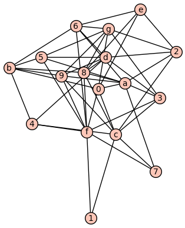

```python
# the correct segments for the digits in order - 0, 1, 2, ... 9
ref_graph_str = "abcefg cf acdeg acdfg bcdf abdfg abdefg acf abcdefg abcdfg"
def makeGraph(s):
    G = Graph()
    for digit, segments in enumerate(s.split()):
        for s in segments:
            G.add_edge(s, digit)
    return G

ref_graph = makeGraph(ref_graph_str)
ref_graph.plot()
```

Hmm... Doesn't look terribly useful? Well, this graph has an important property:

```python
ref_graph.is_bipartite()
```

```
True
```

So, let's try again:

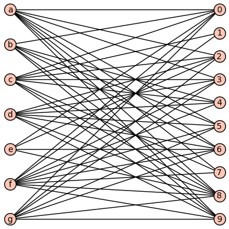

```python
ref_graph = BipartiteGraph(ref_graph)
ref_graph.plot()
```

There are still a lot of edges, but we can clearly see the two independent sets of vertices, with the segments on the left and the digit positions on the right. And given what we know about the problem with it's two inter-related parts (decoding the segment mappings and unshuffling the digits), this may not be surprising.

We can create a graph for any puzzle. Here is the first example from the description page:

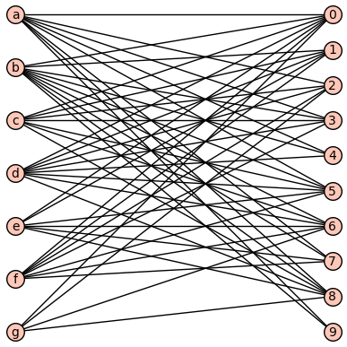

```python
puzzle_graph_str = "acedgfb cdfbe gcdfa fbcad dab cefabd cdfgeb eafb cagedb ab"
puzzle_graph = BipartiteGraph(makeGraph(puzzle_graph_str))
puzzle_graph.plot()
```

The question we're interested in is whether there is a way to map the vertices so that the two graphs are the same. This is exactly what an isomorphism is: [Graph Isomorphism](https://en.wikipedia.org/wiki/Graph_isomorphism) (In this case, we're told that the graphs are isomorphic and we need to find the bijection but it amounts to the same thing).

Let's see what Sage has to say about it:

```python
puzzle_graph.is_isomorphic(ref_graph)
```

```
True
```

That's good. The puzzle is valid. Sage can also provide a "certificate" showing the mapping:

```python
puzzle_graph.is_isomorphic(ref_graph, certificate=True)[1]
```

```
{'a': 'c',
 0: 8,
 'c': 'g',
 'e': 'b',
 'd': 'a',
 'g': 'e',
 'f': 'd',
 'b': 'f',
 1: 5,
 2: 2,
 3: 3,
 4: 7,
 5: 9,
 6: 6,
 7: 4,
 8: 0,
 9: 1}
```

And in one step, Sage has solved the entire problem, both decoding the segment mappings as well as the digit shuffling.

Part 1 of the problem explains how to trivially identify the 1, 4, 7, and 8 because they have a unique number of segments. Interpreted with graph theory, this works because the degree sequence is a graph isomorphism invariant. Two graphs that are isomorphic will have the same degree sequence and so if there is a vertex with a unique degree, it must be mapped to the unique vertex with the same degree in the other graph. Because the graph is bipartite, the vertices on the right can only map to other vertices in that independent set and the vertices on the left can only map to other vertices in that set.

```python
sorted(ref_graph.degree(vertices=[0, 1, 2, 3, 4, 5, 6, 7, 8, 9]))
```

```
[2, 3, 4, 5, 5, 5, 6, 6, 6, 7]
```

Sure enough, 2, 3, 4, and 7 are unique degrees in the right side of the graph, corresponding to the digits 1, 7, 4, and 8. After mapping those digits, we're down to 6 remaining digits or 720 (6!) possible shufflings of the digits. We're left with 3 vertices with degree 5 and 3 vertices with degree 6 which can't be exchanged, so that's actually 3! * 3! = 36 possible shufflings of the digits

This invariant applies to both sides of the graph, so why not look at the other side, too?

```python
sorted(ref_graph.degree(vertices=['a', 'b', 'c', 'd', 'e', 'f', 'g']))
```

```
[4, 6, 7, 7, 8, 8, 9]
```

We're in more luck here. 3 of the 7 segments can be identified immediately just by counting their frequency (degree). The remaining 4 segments split into 2 with degree 7 and 2 with degree 8, so we're looking at 2! * 2! = 4 possible shufflings of the segments.

```python
def segCounts(graph_str):
    counts = {'a': 0, 'b': 0, 'c': 0, 'd': 0, 'e': 0, 'f': 0, 'g': 0, ' ': 0}
    for c in graph_str:
        counts[c] += 1
    return counts

print("Reference Graph: ", segCounts(ref_graph_str))
print("Puzzle Graph: ", segCounts(puzzle_graph_str))
```

```
Reference Graph:  {'a': 8, 'b': 6, 'c': 8, 'd': 7, 'e': 4, 'f': 9, 'g': 7, ' ': 9}
Puzzle Graph:  {'a': 8, 'b': 9, 'c': 7, 'd': 8, 'e': 6, 'f': 7, 'g': 4, ' ': 9}
```

And we immediately see that 'g' maps to 'e', 'e' maps to 'b', and 'b' maps to 'f' We also see that only 'c' or 'f' maps to 'd' or 'g' (and if one maps to one, the other maps to the other) and only 'd' or 'a' maps to 'a' or 'c'.

So we're down to 4 possibilities just by counting the segments.

We can, of course, figure it out pretty easily from here. Digit 1 ("ab") tells us that 'a' maps to only 'c' or 'f' (and not 'a' -> 'a', also from above we know 'b' maps to 'f'), so 'a' maps to 'c' which implies from above that 'd' maps to 'a'. We just need to distinguish between 'd' and 'g' which can be done with digit 4 ("eafb") which has an 'f' and not a 'c' so the 'f' maps to 'd' leaving 'c' to map to 'g'.

(So, for a harder variation of the problem, imagine removing all the spaces, mixing up the letters randomly, with the only guarantee that 1 and 4 are in the first 6 letters).

We can go ahead and remove the mappings the we know so far and look at the degree sequences again (this corresponds to deleting those words and letters from the input and reference lines and building the graphs again):

```python
small_graph = ref_graph.copy()
small_graph.delete_vertices([1, 4, 7, 8, 'e', 'b', 'f'])
print(sorted(small_graph.degree(['a', 'c', 'd', 'g'])))
print(sorted(small_graph.degree([0, 2, 3, 5, 6, 9])))
```

```
[4, 5, 6, 6]
[3, 3, 3, 4, 4, 4]
```

The segment letter degrees have two (out of 4) unique degrees (4, and 5) which we can use to map 2 more letters:

```python
sm_puzzle = puzzle_graph.copy()
sm_puzzle.delete_vertices([9, 7, 4, 0, 'g', 'e', 'b'])  # remove the digits and letters that we know
print(small_graph.degree(['a', 'c', 'd', 'g'], labels=True))
print(sm_puzzle.degree(['a', 'c', 'd', 'f'], labels=True))
```

```
{'a': 6, 'c': 4, 'd': 5, 'g': 6}
{'a': 4, 'c': 6, 'd': 6, 'f': 5}
```

So 'a' maps to 'c' and 'f' maps to 'd' and we're left with just 'a' and 'g' which can be distinguished easily by (only) the 7

We could also look for other graph isomorphism invariants and see if they could be useful:

### Line Graphs

Two simple graphs that are isomorphic have isomorphic line graphs. A line graph is sort of a dual graph with a vertex for every edge and an edge where the edges share a vertex. There are two vertices with unique degree of 7 and 14 so we can match these up:

```python
print([(k, v) for k, v in puzzle_graph.line_graph().degree(labels=True).items() if v == 7 or v == 14])
print([(k, v) for k, v in ref_graph.line_graph().degree(labels=True).items() if v == 7 or v == 14])
```

```
[((0, 'b', None), 14), ((2, 'g', None), 7)]
[((2, 'e', None), 7), ((8, 'f', None), 14)]
```

Which says that 'g' maps to 'e', 'b' maps to 'f' (both of which we know from above) and the digit in the 0th location is an 8 (we already know 8, of course) and the digit in the 2nd (0-based indexing) position is a 2 which is at least some new information.

### Automorphism Group

Can we be sure that our solution is unique? Or can it be that this graph structure allows extra "degrees of freedom" (symmetry) that would allow multiple ways to map the vertices?

For this we will look at the automorphism group of the graph. An automorphism is an isomorphism from the graph into itself and captures symmetry in the graph

```python
ref_graph.automorphism_group().order()
```

```
1
```

There are no non-trivial (non-identity) automorphisms. This is sometimes called a [Rigid Graph](https://mathworld.wolfram.com/RigidGraph.html) which even sounds like what we want.

As an example, let's see what happens when we remove '7':

```python
missing7 = ref_graph.copy()
missing7.delete_vertex(7)
missing7.automorphism_group()
```

```
Permutation Group with generators [('a','g')]
```

Just like we observed with the SAT solver, without 7, 'a' and 'g' can be freely swapped so we don't have a unique mapping of the segments, though the digit mapping (right side of the graph) is stable.

How few digits can we get away with and still have stable digit mappings?

```python
def tryNdigits(N):
    for comb in Combinations(range(10), N):
        subgraph = ref_graph.copy()
        for d in set(range(10)).difference(set(comb)):
            subgraph.delete_vertex(d)
        if subgraph.automorphism_group().order() == 1:
            print(comb)

tryNdigits(1)
tryNdigits(2)
tryNdigits(3)
tryNdigits(4)
```

```
[0, 4, 5, 7]
[2, 3, 4, 7]
[2, 4, 5, 7]
[2, 4, 7, 9]
[3, 4, 5, 7]
[3, 4, 6, 7]
```

These combinations of 4 digits will uniquely map the segments (which can then determine the digits). Some of them may be too easy as they all have unique degrees and we've already noted that 7 may not be necessary, but a few might be interesting. The amount of redundant information in the puzzle is one of the reasons there are so many ways to solve it.

## Conclusion

This post illustrated some new tools (graph theory and SAT solvers) that can be applied to problems like these. Hopefully it was useful and you can think of other ways to use them.